# Introduction to Computer Vision: Plant Seedlings Classification

## Problem Statement

### Context

In recent times, the field of agriculture has been in urgent need of modernizing, since the amount of manual work people need to put in to check if plants are growing correctly is still highly extensive. Despite several advances in agricultural technology, people working in the agricultural industry still need to have the ability to sort and recognize different plants and weeds, which takes a lot of time and effort in the long term. The potential is ripe for this trillion-dollar industry to be greatly impacted by technological innovations that cut down on the requirement for manual labor, and this is where Artificial Intelligence can actually benefit the workers in this field, as **the time and energy required to identify plant seedlings will be greatly shortened by the use of AI and Deep Learning.** The ability to do so far more efficiently and even more effectively than experienced manual labor, could lead to better crop yields, the freeing up of human inolvement for higher-order agricultural decision making, and in the long term will result in more sustainable environmental practices in agriculture as well.

### Objective

The aim of this project is to Build a Convolutional Neural Netowrk to classify plant seedlings into their respective categories.

### Data Dictionary

The Aarhus University Signal Processing group, in collaboration with the University of Southern Denmark, has recently released a dataset containing **images of unique plants belonging to 12 different species.**

- The dataset can be download from Olympus.
- The data file names are:
  - images.npy
  - Labels.csv
- Due to the large volume of data, the images were converted to the images.npy file and the labels are also put into Labels.csv, so that you can work on the data/project seamlessly without having to worry about the high data volume.
- The goal of the project is to create a classifier capable of determining a plant's species from an image.

**List of Species**

- Black-grass
- Charlock
- Cleavers
- Common Chickweed
- Common Wheat
- Fat Hen
- Loose Silky-bent
- Maize
- Scentless Mayweed
- Shepherds Purse
- Small-flowered Cranesbill
- Sugar beet

### **Note: Please use GPU runtime on Google Colab to execute the code faster.**

## Importing necessary libraries

```python
# Installing the libraries with the specified version.
# uncomment and run the following line if Google Colab is being used
!pip install tensorflow==2.15.0 scikit-learn==1.2.2 seaborn==0.13.1 matplotlib==3.7.1 numpy==1.25.2 pandas==1.5.3 opencv-python==4.8.0.76 -q --user
```

[output not shown]

**Note**: *After running the above cell, kindly restart the notebook kernel and run all cells sequentially from the start again.*

```python
import numpy as np
import pandas as pd
import matplotlib.pyplot as plt
import cv2  # This is an important module for reading data
import seaborn as sns  # For data visualization

import tensorflow as tf
from tensorflow.keras.models import Sequential  # Sequential API for sequential model
from tensorflow.keras.layers import Dense, Dropout, Flatten  # Importing different layers
from tensorflow.keras.layers import Conv2D, MaxPooling2D, BatchNormalization, Activation, Input, LeakyReLU
from tensorflow.keras.utils import to_categorical  # To perform one-hot encoding
from tensorflow.keras.optimizers import RMSprop, Adam, SGD  # Optimizers for optimizing the model
from tensorflow.keras.callbacks import EarlyStopping, ModelCheckpoint  # Regularization method to prevent overfitting
from tensorflow.keras.preprocessing.image import ImageDataGenerator  # For data augmentation
from tensorflow.keras.preprocessing.image import img_to_array, load_img  # For image processing
from keras.applications.vgg16 import VGG16  # Importing VGG16 model
```

## Loading the dataset

```python
# Uncomment and run the below code if you are using google colab
from google.colab import drive
drive.mount('/content/drive')
```

```python
#Load the dataset Labels.csv
labels = pd.read_csv('/content/drive/MyDrive/Colab Notebooks/Labels.csv')
```

```python
#Load the images images.npy
images = np.load('/content/drive/MyDrive/Colab Notebooks/images.npy')
```

## Data Overview

### Understand the shape of the dataset

```python
labels.head()
```

|  | Label |
| --- | --- |
| 0 | Small-flowered Cranesbill |
| 1 | Small-flowered Cranesbill |
| 2 | Small-flowered Cranesbill |
| 3 | Small-flowered Cranesbill |
| 4 | Small-flowered Cranesbill |

```python
labels.shape
```

```
(4750, 1)
```

```python
labels.info()
```

```
<class 'pandas.core.frame.DataFrame'>
RangeIndex: 4750 entries, 0 to 4749
Data columns (total 1 columns):
 #   Column  Non-Null Count  Dtype
---  ------  --------------  -----
 0   Label   4750 non-null   object
dtypes: object(1)
memory usage: 37.2+ KB
```

```python
labels.describe()
```

|  | Label |
| --- | --- |
| count | 4750 |
| unique | 12 |
| top | Loose Silky-bent |
| freq | 654 |

## Exploratory Data Analysis

- EDA is an important part of any project involving data.
- It is important to investigate and understand the data better before building a model with it.
- A few questions have been mentioned below which will help you understand the data better.
- A thorough analysis of the data, in addition to the questions mentioned below, should be done.
1. How are these different category plant images different from each other?
2. Is the dataset provided an imbalance? (Check with using bar plots)

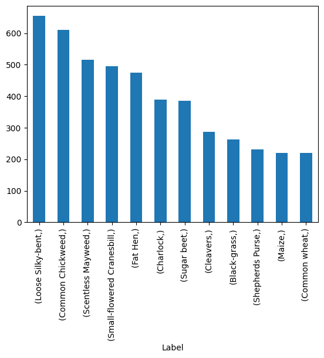

```python
#How are these different category plant images different from each other?
#Plot the different category plant images
labels.value_counts().plot(kind='bar')
```

- Loose Silky bent, Common Chickweek, and Scentless Mayweed are the most frequent dataset
- The dataset is imbalanced as there are a lot of plants that do not have as much labels in the dataset.

## Data Pre-Processing

### Convert the BGR images to RGB images.

```python
#covert the bgr images to rgb images
images = images[:, :, :, ::-1]
```

### Resize the images

```python
import cv2

resized_images = []
for img in images:
    resized_img = cv2.resize(img, (64, 64))
    resized_images.append(resized_img)

resized_images = np.array(resized_images)
```

### Data Preparation for Modeling

- Before you proceed to build a model, you need to split the data into train, test, and validation to be able to evaluate the model that you build on the train data
- You'll have to encode categorical features and scale the pixel values.
- You will build a model using the train data and then check its performance

**Split the dataset**

```python
from sklearn.model_selection import train_test_split

# Split into train and test sets
X_train, X_test, y_train, y_test = train_test_split(images, labels, test_size=0.2, random_state=42)

# Further split train set into train and validation sets
X_train, X_val, y_train, y_val = train_test_split(X_train, y_train, test_size=0.2, random_state=42)
```

### Encode the target labels

```python
from sklearn.preprocessing import LabelEncoder
from tensorflow.keras.utils import to_categorical

# Use the correct column name 'Label'
label_encoder = LabelEncoder()
encoded_labels = label_encoder.fit_transform(labels['Label'])  # 'Label' is the correct column name

# Convert encoded labels to one-hot format
labels = to_categorical(encoded_labels, num_classes=len(np.unique(encoded_labels)))
```

### Data Normalization

```python
#Normalize the data
X_train = X_train/255
X_test = X_test/255
```

## Model Building

```python
# Step 6: Model Architecture
model = Sequential()

# First Convolutional Block
model.add(Conv2D(32, (3, 3), activation='relu', input_shape=(128, 128, 3)))  # Input shape adjusted to (128, 128, 3)
model.add(BatchNormalization())
model.add(MaxPooling2D(pool_size=(2, 2)))
model.add(Dropout(0.25))

# Second Convolutional Block
model.add(Conv2D(64, (3, 3), activation='relu'))
model.add(BatchNormalization())
model.add(MaxPooling2D(pool_size=(2, 2)))
model.add(Dropout(0.25))

# Third Convolutional Block
model.add(Conv2D(128, (3, 3), activation='relu'))
model.add(BatchNormalization())
model.add(MaxPooling2D(pool_size=(2, 2)))
model.add(Dropout(0.25))

# Flatten Layer
model.add(Flatten())  # Flattening the output from the convolutional blocks

# Fully Connected Layers
model.add(Dense(256, activation='relu'))
model.add(Dropout(0.5))
model.add(Dense(12, activation='softmax'))  # Output layer with 12 classes

# Compile the Model
model.compile(optimizer=Adam(learning_rate=0.001),
              loss='categorical_crossentropy',
              metrics=['accuracy'])

# Callbacks
early_stopping = EarlyStopping(monitor='val_loss', patience=10, restore_best_weights=True)
reduce_lr = ReduceLROnPlateau(monitor='val_loss', factor=0.2, patience=5)

# Model Summary
model.summary()
```

```
Model: "sequential_3"
```

```
┏━━━━━━━━━━━━━━━━━━━━━━━━━━━━━━━━━━━━━━┳━━━━━━━━━━━━━━━━━━━━━━━━━━━━━┳━━━━━━━━━━━━━━━━━┓
┃ Layer (type)                         ┃ Output Shape                ┃         Param # ┃
┡━━━━━━━━━━━━━━━━━━━━━━━━━━━━━━━━━━━━━━╇━━━━━━━━━━━━━━━━━━━━━━━━━━━━━╇━━━━━━━━━━━━━━━━━┩
│ conv2d_9 (Conv2D)                    │ (None, 126, 126, 32)        │             896 │
├──────────────────────────────────────┼─────────────────────────────┼─────────────────┤
│ batch_normalization_9                │ (None, 126, 126, 32)        │             128 │
│ (BatchNormalization)                 │                             │                 │
├──────────────────────────────────────┼─────────────────────────────┼─────────────────┤
│ max_pooling2d_9 (MaxPooling2D)       │ (None, 63, 63, 32)          │               0 │
├──────────────────────────────────────┼─────────────────────────────┼─────────────────┤
│ dropout_12 (Dropout)                 │ (None, 63, 63, 32)          │               0 │
├──────────────────────────────────────┼─────────────────────────────┼─────────────────┤
│ conv2d_10 (Conv2D)                   │ (None, 61, 61, 64)          │          18,496 │
├──────────────────────────────────────┼─────────────────────────────┼─────────────────┤
│ batch_normalization_10               │ (None, 61, 61, 64)          │             256 │
│ (BatchNormalization)                 │                             │                 │
├──────────────────────────────────────┼─────────────────────────────┼─────────────────┤
│ max_pooling2d_10 (MaxPooling2D)      │ (None, 30, 30, 64)          │               0 │
├──────────────────────────────────────┼─────────────────────────────┼─────────────────┤
│ dropout_13 (Dropout)                 │ (None, 30, 30, 64)          │               0 │
├──────────────────────────────────────┼─────────────────────────────┼─────────────────┤
│ conv2d_11 (Conv2D)                   │ (None, 28, 28, 128)         │          73,856 │
├──────────────────────────────────────┼─────────────────────────────┼─────────────────┤
│ batch_normalization_11               │ (None, 28, 28, 128)         │             512 │
│ (BatchNormalization)                 │                             │                 │
├──────────────────────────────────────┼─────────────────────────────┼─────────────────┤
│ max_pooling2d_11 (MaxPooling2D)      │ (None, 14, 14, 128)         │               0 │
├──────────────────────────────────────┼─────────────────────────────┼─────────────────┤
│ dropout_14 (Dropout)                 │ (None, 14, 14, 128)         │               0 │
├──────────────────────────────────────┼─────────────────────────────┼─────────────────┤
│ flatten_3 (Flatten)                  │ (None, 25088)               │               0 │
├──────────────────────────────────────┼─────────────────────────────┼─────────────────┤
│ dense_6 (Dense)                      │ (None, 256)                 │       6,422,784 │
├──────────────────────────────────────┼─────────────────────────────┼─────────────────┤
│ dropout_15 (Dropout)                 │ (None, 256)                 │               0 │
├──────────────────────────────────────┼─────────────────────────────┼─────────────────┤
│ dense_7 (Dense)                      │ (None, 12)                  │           3,084 │
└──────────────────────────────────────┴─────────────────────────────┴─────────────────┘
```

```
 Total params: 6,520,012 (24.87 MB)
```

```
 Trainable params: 6,519,564 (24.87 MB)
```

```
 Non-trainable params: 448 (1.75 KB)
```

## Model Performance Improvement

**Reducing the Learning Rate:**

**Hint**: Use **ReduceLRonPlateau()** function that will be used to decrease the learning rate by some factor, if the loss is not decreasing for some time. This may start decreasing the loss at a smaller learning rate. There is a possibility that the loss may still not decrease. This may lead to executing the learning rate reduction again in an attempt to achieve a lower loss.

### **Data Augmentation**

Remember, **data augmentation should not be used in the validation/test data set**.

## Final Model

```
Model: "sequential_4"
```

```
┏━━━━━━━━━━━━━━━━━━━━━━━━━━━━━━━━━━━━━━┳━━━━━━━━━━━━━━━━━━━━━━━━━━━━━┳━━━━━━━━━━━━━━━━━┓
┃ Layer (type)                         ┃ Output Shape                ┃         Param # ┃
┡━━━━━━━━━━━━━━━━━━━━━━━━━━━━━━━━━━━━━━╇━━━━━━━━━━━━━━━━━━━━━━━━━━━━━╇━━━━━━━━━━━━━━━━━┩
│ conv2d_12 (Conv2D)                   │ (None, 126, 126, 32)        │             896 │
├──────────────────────────────────────┼─────────────────────────────┼─────────────────┤
│ batch_normalization_12               │ (None, 126, 126, 32)        │             128 │
│ (BatchNormalization)                 │                             │                 │
├──────────────────────────────────────┼─────────────────────────────┼─────────────────┤
│ max_pooling2d_12 (MaxPooling2D)      │ (None, 63, 63, 32)          │               0 │
├──────────────────────────────────────┼─────────────────────────────┼─────────────────┤
│ dropout_16 (Dropout)                 │ (None, 63, 63, 32)          │               0 │
├──────────────────────────────────────┼─────────────────────────────┼─────────────────┤
│ conv2d_13 (Conv2D)                   │ (None, 61, 61, 64)          │          18,496 │
├──────────────────────────────────────┼─────────────────────────────┼─────────────────┤
│ batch_normalization_13               │ (None, 61, 61, 64)          │             256 │
│ (BatchNormalization)                 │                             │                 │
├──────────────────────────────────────┼─────────────────────────────┼─────────────────┤
│ max_pooling2d_13 (MaxPooling2D)      │ (None, 30, 30, 64)          │               0 │
├──────────────────────────────────────┼─────────────────────────────┼─────────────────┤
│ dropout_17 (Dropout)                 │ (None, 30, 30, 64)          │               0 │
├──────────────────────────────────────┼─────────────────────────────┼─────────────────┤
│ conv2d_14 (Conv2D)                   │ (None, 28, 28, 128)         │          73,856 │
├──────────────────────────────────────┼─────────────────────────────┼─────────────────┤
│ batch_normalization_14               │ (None, 28, 28, 128)         │             512 │
│ (BatchNormalization)                 │                             │                 │
├──────────────────────────────────────┼─────────────────────────────┼─────────────────┤
│ max_pooling2d_14 (MaxPooling2D)      │ (None, 14, 14, 128)         │               0 │
├──────────────────────────────────────┼─────────────────────────────┼─────────────────┤
│ dropout_18 (Dropout)                 │ (None, 14, 14, 128)         │               0 │
├──────────────────────────────────────┼─────────────────────────────┼─────────────────┤
│ flatten_4 (Flatten)                  │ (None, 25088)               │               0 │
├──────────────────────────────────────┼─────────────────────────────┼─────────────────┤
│ dense_8 (Dense)                      │ (None, 256)                 │       6,422,784 │
├──────────────────────────────────────┼─────────────────────────────┼─────────────────┤
│ dropout_19 (Dropout)                 │ (None, 256)                 │               0 │
├──────────────────────────────────────┼─────────────────────────────┼─────────────────┤
│ dense_9 (Dense)                      │ (None, 12)                  │           3,084 │
└──────────────────────────────────────┴─────────────────────────────┴─────────────────┘
```

```
 Total params: 6,520,012 (24.87 MB)
```

```
 Trainable params: 6,519,564 (24.87 MB)
```

```
 Non-trainable params: 448 (1.75 KB)
```

```
95/95 ━━━━━━━━━━━━━━━━━━━━ 28s 175ms/step - accuracy: 0.1141 - loss: 6.5445 - val_accuracy: 0.0513 - val_loss: 18.4012 - learning_rate: 0.0010
95/95 ━━━━━━━━━━━━━━━━━━━━ 14s 138ms/step - accuracy: 0.1713 - loss: 2.4420 - val_accuracy: 0.1395 - val_loss: 5.9918 - learning_rate: 0.0010
95/95 ━━━━━━━━━━━━━━━━━━━━ 14s 136ms/step - accuracy: 0.2304 - loss: 2.3009 - val_accuracy: 0.1566 - val_loss: 5.5641 - learning_rate: 0.0010
95/95 ━━━━━━━━━━━━━━━━━━━━ 23s 158ms/step - accuracy: 0.2401 - loss: 2.2394 - val_accuracy: 0.2776 - val_loss: 2.3939 - learning_rate: 0.0010
95/95 ━━━━━━━━━━━━━━━━━━━━ 19s 138ms/step - accuracy: 0.2188 - loss: 2.2190 - val_accuracy: 0.2908 - val_loss: 2.2428 - learning_rate: 0.0010
95/95 ━━━━━━━━━━━━━━━━━━━━ 20s 135ms/step - accuracy: 0.2492 - loss: 2.1704 - val_accuracy: 0.2197 - val_loss: 2.5941 - learning_rate: 0.0010
95/95 ━━━━━━━━━━━━━━━━━━━━ 14s 137ms/step - accuracy: 0.2461 - loss: 2.1566 - val_accuracy: 0.1158 - val_loss: 3.0545 - learning_rate: 0.0010
95/95 ━━━━━━━━━━━━━━━━━━━━ 19s 119ms/step - accuracy: 0.2458 - loss: 2.1157 - val_accuracy: 0.2868 - val_loss: 2.4920 - learning_rate: 0.0010
95/95 ━━━━━━━━━━━━━━━━━━━━ 21s 133ms/step - accuracy: 0.2474 - loss: 2.1227 - val_accuracy: 0.3000 - val_loss: 2.3407 - learning_rate: 0.0010
95/95 ━━━━━━━━━━━━━━━━━━━━ 0s 125ms/step - accuracy: 0.2527 - loss: 2.0977
Epoch 10: ReduceLROnPlateau reducing learning rate to 0.00020000000949949026.
95/95 ━━━━━━━━━━━━━━━━━━━━ 20s 127ms/step - accuracy: 0.2527 - loss: 2.0982 - val_accuracy: 0.0895 - val_loss: 4.3784 - learning_rate: 0.0010
95/95 ━━━━━━━━━━━━━━━━━━━━ 14s 138ms/step - accuracy: 0.2505 - loss: 2.0961 - val_accuracy: 0.2382 - val_loss: 3.5538 - learning_rate: 2.0000e-04
95/95 ━━━━━━━━━━━━━━━━━━━━ 20s 134ms/step - accuracy: 0.2593 - loss: 2.0663 - val_accuracy: 0.2461 - val_loss: 2.4572 - learning_rate: 2.0000e-04
95/95 ━━━━━━━━━━━━━━━━━━━━ 14s 137ms/step - accuracy: 0.2521 - loss: 2.0759 - val_accuracy: 0.2724 - val_loss: 2.1591 - learning_rate: 2.0000e-04
95/95 ━━━━━━━━━━━━━━━━━━━━ 14s 137ms/step - accuracy: 0.2622 - loss: 2.0691 - val_accuracy: 0.3211 - val_loss: 1.9511 - learning_rate: 2.0000e-04
95/95 ━━━━━━━━━━━━━━━━━━━━ 14s 136ms/step - accuracy: 0.2741 - loss: 2.0412 - val_accuracy: 0.3263 - val_loss: 1.9459 - learning_rate: 2.0000e-04
95/95 ━━━━━━━━━━━━━━━━━━━━ 22s 151ms/step - accuracy: 0.2583 - loss: 2.0742 - val_accuracy: 0.3224 - val_loss: 1.9205 - learning_rate: 2.0000e-04
95/95 ━━━━━━━━━━━━━━━━━━━━ 19s 135ms/step - accuracy: 0.2747 - loss: 2.0355 - val_accuracy: 0.3224 - val_loss: 1.9191 - learning_rate: 2.0000e-04
95/95 ━━━━━━━━━━━━━━━━━━━━ 21s 136ms/step - accuracy: 0.2709 - loss: 2.0355 - val_accuracy: 0.3211 - val_loss: 1.9314 - learning_rate: 2.0000e-04
95/95 ━━━━━━━━━━━━━━━━━━━━ 14s 136ms/step - accuracy: 0.2591 - loss: 2.0270 - val_accuracy: 0.3184 - val_loss: 1.9243 - learning_rate: 2.0000e-04
95/95 ━━━━━━━━━━━━━━━━━━━━ 14s 137ms/step - accuracy: 0.2734 - loss: 2.0151 - val_accuracy: 0.3026 - val_loss: 2.1244 - learning_rate: 2.0000e-04
95/95 ━━━━━━━━━━━━━━━━━━━━ 21s 138ms/step - accuracy: 0.2959 - loss: 1.9828 - val_accuracy: 0.3316 - val_loss: 1.9328 - learning_rate: 2.0000e-04
94/95 ━━━━━━━━━━━━━━━━━━━━ 0s 130ms/step - accuracy: 0.2731 - loss: 2.0030
Epoch 22: ReduceLROnPlateau reducing learning rate to 4.0000001899898055e-05.
95/95 ━━━━━━━━━━━━━━━━━━━━ 13s 132ms/step - accuracy: 0.2733 - loss: 2.0028 - val_accuracy: 0.3250 - val_loss: 1.9417 - learning_rate: 2.0000e-04
95/95 ━━━━━━━━━━━━━━━━━━━━ 13s 130ms/step - accuracy: 0.2908 - loss: 1.9746 - val_accuracy: 0.3447 - val_loss: 1.8957 - learning_rate: 4.0000e-05
95/95 ━━━━━━━━━━━━━━━━━━━━ 21s 135ms/step - accuracy: 0.3023 - loss: 1.9589 - val_accuracy: 0.3618 - val_loss: 1.8638 - learning_rate: 4.0000e-05
95/95 ━━━━━━━━━━━━━━━━━━━━ 13s 134ms/step - accuracy: 0.2866 - loss: 1.9854 - val_accuracy: 0.3632 - val_loss: 1.8608 - learning_rate: 4.0000e-05
95/95 ━━━━━━━━━━━━━━━━━━━━ 20s 132ms/step - accuracy: 0.2828 - loss: 1.9608 - val_accuracy: 0.3592 - val_loss: 1.8729 - learning_rate: 4.0000e-05
95/95 ━━━━━━━━━━━━━━━━━━━━ 21s 136ms/step - accuracy: 0.3033 - loss: 1.9460 - val_accuracy: 0.3684 - val_loss: 1.8845 - learning_rate: 4.0000e-05
95/95 ━━━━━━━━━━━━━━━━━━━━ 23s 158ms/step - accuracy: 0.3032 - loss: 1.9530 - val_accuracy: 0.3592 - val_loss: 1.9021 - learning_rate: 4.0000e-05
95/95 ━━━━━━━━━━━━━━━━━━━━ 19s 138ms/step - accuracy: 0.2896 - loss: 1.9633 - val_accuracy: 0.3605 - val_loss: 1.8594 - learning_rate: 4.0000e-05
95/95 ━━━━━━━━━━━━━━━━━━━━ 14s 136ms/step - accuracy: 0.3023 - loss: 1.9711 - val_accuracy: 0.3553 - val_loss: 1.8605 - learning_rate: 4.0000e-05
```

[output cut: 17 more lines]

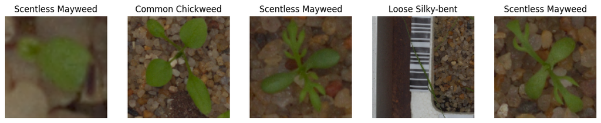

```python
# Required Imports
import numpy as np
import pandas as pd
from sklearn.model_selection import train_test_split
from sklearn.preprocessing import LabelEncoder
from tensorflow.keras.models import Sequential
from tensorflow.keras.layers import Conv2D, MaxPooling2D, Flatten, Dense, Dropout, BatchNormalization
from tensorflow.keras.optimizers import Adam
from tensorflow.keras.utils import to_categorical
from tensorflow.keras.callbacks import EarlyStopping, ReduceLROnPlateau
from tensorflow.keras.preprocessing.image import ImageDataGenerator
import matplotlib.pyplot as plt

# Assuming images and labels are already loaded and preprocessed as follows:
# images = ... (loaded from images.npy)
# labels_df = ... (loaded from Labels.csv)
# encoded_labels = ... (label encoding process)
# labels = ... (one-hot encoding process)
# Normalize the images
images = images / 255.0  # Scale pixel values to [0, 1]

# Step 4: Split the data into train, validation, and test sets
X_train, X_test, y_train, y_test = train_test_split(images, labels, test_size=0.2, random_state=42)
X_train, X_val, y_train, y_val = train_test_split(X_train, y_train, test_size=0.2, random_state=42)

# Step 5: Data Augmentation Setup
datagen = ImageDataGenerator(
    rotation_range=20,
    width_shift_range=0.2,
    height_shift_range=0.2,
    shear_range=0.2,
    zoom_range=0.2,
    horizontal_flip=True,
    fill_mode='nearest'
)

# Fit the generator to the training data
datagen.fit(X_train)

# Step 6: Model Architecture
model = Sequential()

# First Convolutional Block
model.add(Conv2D(32, (3, 3), activation='relu', input_shape=(128, 128, 3)))  # Input shape
model.add(BatchNormalization())
model.add(MaxPooling2D(pool_size=(2, 2)))
model.add(Dropout(0.25))

# Second Convolutional Block
model.add(Conv2D(64, (3, 3), activation='relu'))
model.add(BatchNormalization())
model.add(MaxPooling2D(pool_size=(2, 2)))
model.add(Dropout(0.25))

# Third Convolutional Block
model.add(Conv2D(128, (3, 3), activation='relu'))
model.add(BatchNormalization())
model.add(MaxPooling2D(pool_size=(2, 2)))
model.add(Dropout(0.25))

# Flatten Layer
model.add(Flatten())  # Flattening the output from the convolutional blocks

# Fully Connected Layers
model.add(Dense(256, activation='relu'))
model.add(Dropout(0.5))
model.add(Dense(12, activation='softmax'))  # Output layer with 12 classes

# Compile the Model
model.compile(optimizer=Adam(learning_rate=0.001),
              loss='categorical_crossentropy',
              metrics=['accuracy'])

# Callbacks
early_stopping = EarlyStopping(monitor='val_loss', patience=10, restore_best_weights=True)
reduce_lr = ReduceLROnPlateau(monitor='val_loss', factor=0.2, patience=5, verbose=1)

# Model Summary
model.summary()

# Model Training with Data Augmentation and Learning Rate Reduction
history = model.fit(datagen.flow(X_train, y_train, batch_size=32),
                    validation_data=(X_val, y_val),
                    epochs=50,
                    callbacks=[early_stopping, reduce_lr])

# Optional: Function to visualize images
def plot_images(images, labels, num=5):
    plt.figure(figsize=(15, 5))
    for i in range(num):
        plt.subplot(1, num, i + 1)
        plt.imshow(images[i])
        plt.title(label_encoder.inverse_transform([np.argmax(labels[i])])[0])  # Convert back to original label
        plt.axis('off')
    plt.show()

# Display some training images
plot_images(X_train, y_train)
```

### Visualizing the prediction

```
30/30 ━━━━━━━━━━━━━━━━━━━━ 2s 58ms/step
```

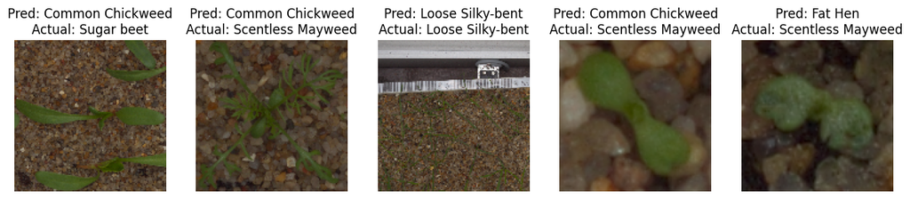

```python
# Function to visualize predictions
def visualize_predictions(model, X_test, y_test, num_images=5):
    # Generate predictions
    predictions = model.predict(X_test)

    # Select a random subset of images
    indices = np.random.choice(len(X_test), num_images, replace=False)

    plt.figure(figsize=(15, 5))
    for i, index in enumerate(indices):
        plt.subplot(1, num_images, i + 1)

        # Display the image
        plt.imshow(X_test[index])

        # Get the predicted and actual labels
        predicted_label = np.argmax(predictions[index])
        actual_label = np.argmax(y_test[index])

        # Convert back to original label
        predicted_label_name = label_encoder.inverse_transform([predicted_label])[0]
        actual_label_name = label_encoder.inverse_transform([actual_label])[0]

        plt.title(f"Pred: {predicted_label_name}\nActual: {actual_label_name}")
        plt.axis('off')

    plt.show()

# Visualize predictions on the test set
visualize_predictions(model, X_test, y_test, num_images=5)
```

## Actionable Insights and Business Recommendations

Actionable Insights Model Performance:

Common Misclassifications: Analyze which species are most commonly misclassified. Understanding these misclassifications can highlight similarities in plant characteristics that may confuse the model. Feature Importance:

Visualize Features: Use techniques like Grad-CAM or saliency maps to understand which features of the images (e.g., leaf shape, color) contribute most to the predictions. This could help in refining the model or identifying key characteristics of different species. Data Augmentation Impact:

Evaluate Augmentation Effects: Determine the effect of data augmentation on model performance. Analyze whether augmenting the dataset helped improve the model’s generalization capabilities. Business Recommendations Enhancing Model Training:

Continuous Model Improvement: Regularly retrain the model with new data to improve its accuracy. Incorporate user feedback to identify areas of improvement and expand the dataset with more examples, especially for misclassified species. Integration into Applications:

Develop an Application: Create a user-friendly application or tool that utilizes the model for real-time plant species identification. This could be targeted toward gardening enthusiasts, botanists, or agricultural workers. Education and Awareness:

User Education: Provide educational content alongside the application, helping users understand plant characteristics, care tips, and potential uses. This could enhance user engagement and satisfaction. Market Targeting:

Identify Target Users: Focus on specific user groups such as horticulturists, landscape architects, or environmental researchers who may benefit from accurate plant identification and insights into plant health. Strategic Partnerships:

Collaborate with Botanical Gardens and Research Institutions: Partner with organizations to collect more diverse data, validate the model’s predictions, and explore practical applications in conservation efforts. Feedback Loop:

Implement a Feedback Mechanism: Allow users to provide feedback on the accuracy of the predictions. This feedback can be invaluable for refining the model over time. Conclusion By leveraging the insights gained from model training and predictions, organizations can enhance their decision-making processes, improve customer engagement, and develop innovative solutions in plant species identification. Regularly revisiting and refining the model based on new data and user feedback will ensure that the system remains robust and effective in meeting user needs.